# PROJECT PART 2

```python
import numpy as np
import matplotlib.pyplot as plt
import pandas as pd
import cv2
from sklearn.feature_extraction import image
from sklearn.linear_model import LinearRegression
import statistics
import random
```

```python
img=cv2.imread("group_4.jpg")
```

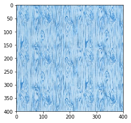

```python
plt.imshow(img)
```

[Reference coefficient values for converting RGB values to grayscale](https://docs.opencv.org/2.4/modules/imgproc/doc/miscellaneous_transformations.html#void%20cvtColor%28InputArray%20src,%20OutputArray%20dst,%20int%20code,%20int%20dstCn%29)

```python
grayimg = img.copy()
height, width, channels = grayimg.shape
for i in range(height):
    for j in range(width):
        grayimg[i,j] = 0.299 * img[i,j][0] + 0.587 * img[i,j][1] +  0.114 * img[i,j][2]
```

```python
grayimg = grayimg[:, :, 0]
print(grayimg.shape)
```

```
(400, 400)
```

#### We droped the RGB values for manipulating with 400 x 400 pixels. Now it is 400 x 400 2 Dimensional array.

#### The code that we used in R programming to achieve 122500 x 2601 array is below, but it lasts very much time to run the code and take output. So we decided to do this part of the project in python

df<-array(0,dim = c(122500,2601))  
df<-data.frame(df)  
image_windows<-img_g

for (i in c(1:1)) {  
lleft<-(i)  
lright<-(50+i)

for(j in c(1:350)){  
new_windows<-image_windows[j:(50+j),lleft:lright]  
dim(new_windows)<-c(1,2601)  
a<-j+(i-1)*350  
df[a,]<-new_windows  
} }

#### In here we extracted all possible patches of our image and the package extracted 122500 patch.Because the all possible patches are 51 x 51 array, so we should form 1 x 2601 array for all of these images to create a linear regression model.

```python
possible_patches = image.extract_patches_2d(grayimg, (51, 51))
```

```python
model_array=possible_patches.reshape((122500,2601))
model_array=pd.DataFrame(model_array)
```

```python
y=model_array[1301]
X=model_array.drop([1301],axis=1)
```

```python
lm=LinearRegression()
lm.fit(X,y)
```

```
LinearRegression(copy_X=True, fit_intercept=True, n_jobs=None,
         normalize=False)
```

```python
predicted_pixels=lm.predict(X)
```

#### When we tried to make linear regression by using all 122500 rows, lm.fit function gave memory error . Therefore we selected randomly 60000 rows and constructed one regression model for those pixels and predicted our y values according to that model.However when we tried to run lm function with 122500 rows in another computer we were able take results, so we continued with that computer and also left our first code here.

newArray=random.sample(range(0, 122500), 60000)

random_array=0  
random_array=pd.DataFrame

k=newArray[0]  
random_array=model_array.loc[[k]]  
for i in range(59999):  
k=newArray[i+1]  
random_array=random_array.append(model_array.loc[[k]])

lm=LinearRegression()  
lm.fit(random_array.drop(columns=[1301]),random_array[1301])  
predicted_pixels=lm.predict(X)

```python
predicted_pixels.shape
```

```
(122500,)
```

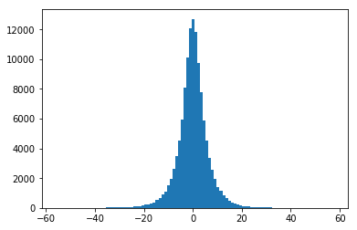

```python
residuals=y-predicted_pixels
plt.hist(residuals,bins=100)
```

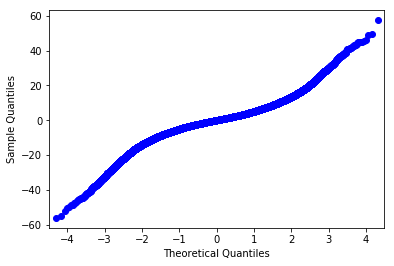

```python
import statsmodels.api as sm
fig = sm.qqplot(residuals)
plt.show()
```

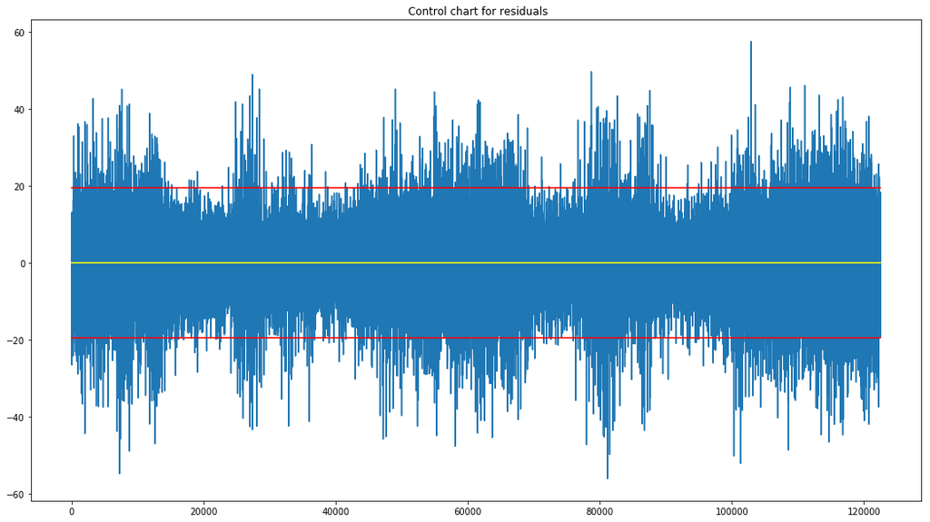

```python
mean=statistics.mean(residuals)
std=statistics.stdev(residuals)
UCL=mean+3*std
LCL=mean-3*std

fig,ax=plt.subplots(1,1,figsize=(18,10))
ax.plot(residuals)
ax.plot(np.linspace(UCL,UCL,122500),color="red")
ax.plot(np.linspace(LCL,LCL,122500),color="red")
ax.plot(np.linspace(mean,mean,122500),color="yellow")
ax.set_title(" Control chart for residuals")
```

```python
last_image=grayimg.copy()[25:375,26:376].flatten()
```

```python
(y==last_image).head(10)
```

```
0    True
1    True
2    True
3    True
4    True
5    True
6    True
7    True
8    True
9    True
Name: 1301, dtype: bool
```

```python
for i in range(122500):
    if (residuals[i]<LCL)|(residuals[i]>UCL):
        last_image[i]=0
```

```python
last_image=last_image.reshape((350,350))
pict=grayimg.copy()
pict[25:375,26:376]=last_image
```

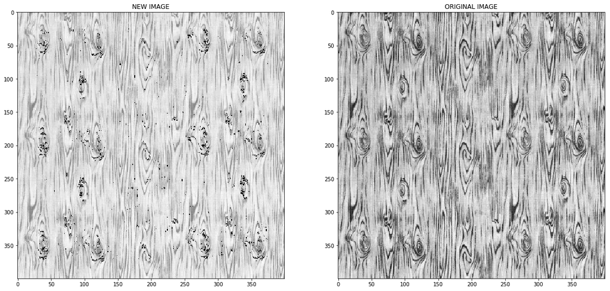

```python
fig,ax=plt.subplots(ncols=2,figsize=(20,22))
ax[0].imshow(pict,cmap="gray")
ax[0].set_title("NEW IMAGE")
ax[1].imshow(grayimg,cmap="gray")
ax[1].set_title("ORIGINAL IMAGE")
```

#### One way of reducing autocorrelation is to remove one or more of the violating predictors from the regression model. Another way is to collect additional data under different experimental or observational conditions.